Bo Suzow

February 15, 2018

## Introduction

The purpose of this report is to demonstrate how to collect Twitter tweets on search patterns and to build a word cloud. In order to collect Twitter data, you need to have a Twitter account and create an app at apps.twitter.com.

## Data Collection

The following code collect tweets of the ##GunReformNow hasgtag using [the rtweet package](https://cran.r-project.org/web/packages/rtweet/rtweet.pdf). The package is developed by [Mr. Kearney](https://github.com/mkearney/rtweet).

Quick examples of functions of the package are [here](https://github.com/mkearney/rtweet/blob/master/vignettes/intro.Rmd).

Note: Another package possibly used for Twitter data collect is twitteR. TwitteR pulls tweets in truncated text. Hence, it is not a good choice for a word cloud.

For API Authentication, creating the token, saving it in RDS and setting the TWITTER_PAT environment var have to be completed. The detail steps are [here](https://github.com/mkearney/rtweet/blob/master/vignettes/auth.Rmd).

```r
library("rtweet")

# The following statement should be uncommented when a new tweet collection is intended.

tweetsGunReform = search_tweets("#GunReformNow OR #gunreformnow OR \"Gun Reform Now\" OR \"gun reform now\"",
                         n=15000,
                         include_rts=FALSE,
                         lang="en")
```

## Tweet Text Clean-up

Before buildling a word cloud, unwanted characters should be removed. The following code is borrowed (with a minor tweak) from [a blog authored by Bailey Adam and Sugandha Choudhary](https://www.credera.com/blog/business-intelligence/twitter-analytics-using-r-part-2-create-word-cloud/)

```r
# Convert all text to lowercase
library(stringi) # to use string's stri_trans_tolower()

tweets.text = stringi::stri_trans_tolower(tweetsGunReform$text) # the tolower() does not handle special characters often embeded in tweets.

# https://stackoverflow.com/questions/9637278/r-tm-package-invalid-input-in-utf8towcs
library(stringr)
usableText=str_replace_all(tweets.text,"[^[:graph:]]", " ")

tweets.text = iconv(tweets.text,"latin1","ASCII"," ")

# Replace @UserName
tweets.text <- gsub("@\\w+", " ", tweets.text)

# Remove punctuation
tweets.text <- gsub("[[:punct:]]", " ", tweets.text)

# Remove links
tweets.text <- gsub("http\\w+", "", tweets.text)

# Remove tabs
tweets.text <- gsub("[ |\t]{2,}", " ", tweets.text)

# Remove blank spaces at the beginning
tweets.text <- gsub("^ ", "", tweets.text)

# Remove blank spaces at the end
tweets.text <- gsub(" $", "", tweets.text)
```

## [Stop Words](https://en.wikipedia.org/wiki/Stop_words) Removal

Removing commonly used words such as “the” is achieved with [the tm package](https://cran.r-project.org/web/packages/tm/vignettes/tm.pdf)

```r
library(tm)

# create corpus
tweets.text.corpus <- Corpus(VectorSource(tweets.text))

#clean up by removing stop words
tweets.text.corpus <- tm_map(tweets.text.corpus,function(x)removeWords(x,stopwords()))
```

## Build A Word Cloud

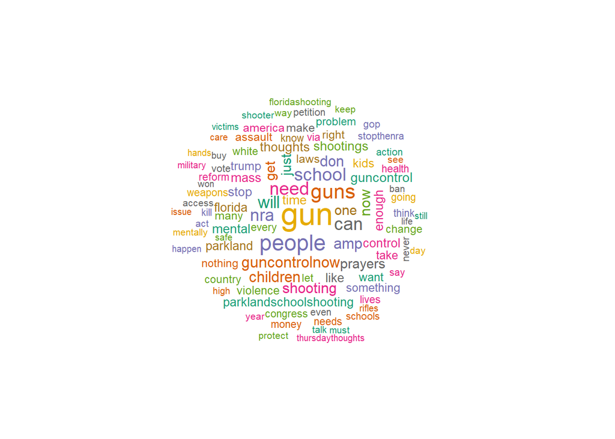

```r
library(wordcloud)
wordcloud(tweets.text.corpus,
          min.freq = 2,
          scale=c(7,0.5),
          colors=brewer.pal(8, "Dark2"),
          random.color= TRUE,
          random.order = FALSE,
          max.words = 100)
```

What does the cloud tell us? Does the textual data visualization give insights or serve “just as eye candy?” [The “What are word clouds”" article](http://www.boostlabs.com/what-are-word-clouds-value-simple-visualizations/) offers good pieces of advice.